# LAX Ground Vehicle Traffic Volume Forecasting

Brady Chiu

August 07, 2016

# 1 TL;DR

- **Objective:** Forecast LAX ground vehicle traffic volume for the year of 2017
- **Apporach:** We assessed 3 forecasting models: STL Decomposition, Holt-Winters Exponential Smoothing, and Arima
- **Finding:** STL Decomposition forecasting was most accurate, predicting ~40MM vehicles will pass through LAX in 2017

```r
knitr::read_chunk("../code/main.R")
knitr::opts_chunk$set(fig.height=5, fig.width=8)
```

```r
# todo:
# 1) redo analysis with repeated k-folds cross validation, given the small sample size
```

```r
work_dir="/Users/bradychiu/Dropbox/r/lax_ground_vehicle_traffic_volume"
data_dir="data/"
deliverable_dir="deliverables/"
# setwd(work_dir)

package_loader<-function(package_names){
  for(i in package_names){
    if(!i %in% rownames(installed.packages())) install.packages(i, repos="http://cran.r-project.org")
    library(i, character.only=T)
  }
}
package_names<-c("data.table", "dplyr", "forecast", "ggplot2", "knitr", "lubridate", "stats", "stringr", "tidyr", "tseries")
package_loader(package_names)
```

```r
get_data<-function(data_file_paths){
  bind_rows(lapply(data_file_paths, fread, na.strings="", stringsAsFactors=F)) %>%
    data.frame()
}

get_table<-function(df,dig=2){
  kable(df, align='r', digits=dig, format.args=list(big.mark=","))
}

# calculate mean absolute error
get_mae<-function(actuals, predicted){
  err<-abs(actuals-predicted)
  return (mean(err))
}
# calculate mean absolute percentage error
get_mape<-function(actuals, predicted){
  err<-abs(actuals-predicted)/actuals
  return (mean(err))
}
# calculate mean squared error
get_mse<-function(actuals, predicted){
  err<-(actuals-predicted)^2
  return(mean(err))
}
# calculate mean percentage error
get_mpe<-function(actuals, predicted){
  err<-(actuals-predicted)/actuals
  return(mean(err))
}
```

```r
validation_periods<-3
```

```r
# file.remove(file.path(work_dir, data_dir, "lax_ground_vehicle_traffic_volume.Rds"))
if(!file.exists(file.path(work_dir, data_dir, "lax_ground_vehicle_traffic_volume.Rds"))){
  file_names<-c(
    "Los_Angeles_International_Airport_-_Ground_Vehicle_Traffic_Volume.csv"
  )
  lax_ground_vehicle_traffic_volume<-get_data(file.path(work_dir, data_dir, file_names)) %>%
    mutate(ReportingMonth=mdy_hms(ReportingMonth, tz="America/Los_Angeles")) %>%
    dplyr::rename(reporting_month=ReportingMonth,
                  action=EntryExit,
                  level=UpperLower,
                  vehicles=TOTAL.VEHICLES) %>%
    arrange(reporting_month, action, level)
  saveRDS(lax_ground_vehicle_traffic_volume, file.path(work_dir, data_dir, "lax_ground_vehicle_traffic_volume.Rds"))
}else{
  lax_ground_vehicle_traffic_volume<-readRDS(file.path(work_dir, data_dir, "lax_ground_vehicle_traffic_volume.Rds"))
}
```

# 2 Setup

## 2.1 Validation Data

To setup the data for our analysis, we’ll take the last 3 months and set them aside for validation. We’ll use the remaining data to train our models.

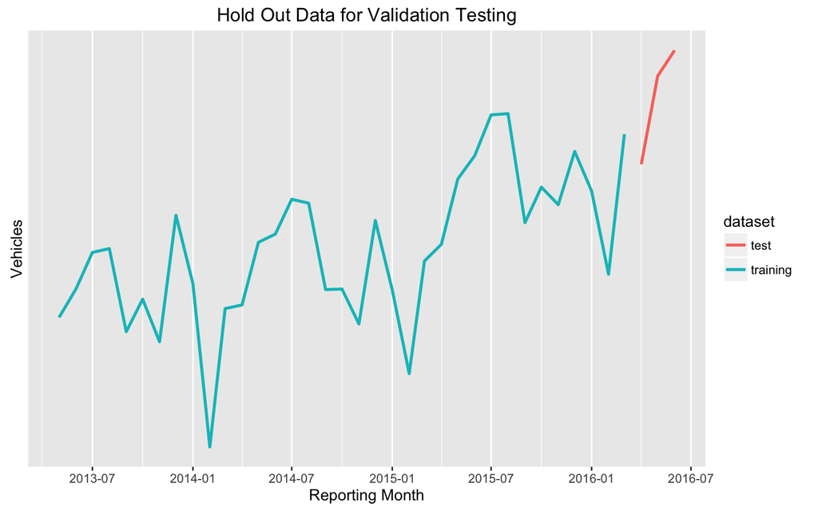

```r
lax_vehicles<-lax_ground_vehicle_traffic_volume_cleaned %>%
  mutate(dataset=ifelse(row_number()<=nrow(.)-validation_periods, "training", "test"))
lax.training<-lax_vehicles %>%
  filter(dataset=="training") %>%
  dplyr::select(-dataset)
lax.test<-lax_vehicles %>%
  filter(dataset=="test") %>%
  dplyr::select(-dataset)

lax_vehicles %>%
  ggplot(aes(x=reporting_month, y=vehicles, color=dataset))+
  geom_line(size=1)+
  ggtitle("Hold Out Data for Validation Testing")+
  scale_x_datetime(name="Reporting Month")+
  scale_y_continuous(name="Vehicles",
                     breaks=seq(-1000000,1000000,250000),
                     labels=format(seq(-1000000,1000000,250000), big.mark=",", scientific=F))
```

```r
lax.ts12<-ts(lax.training$vehicles, frequency=12, start=c(year(min(lax.training$reporting_month)),
                                                          month(min(lax.training$reporting_month))))
lax.ts12
```

```
##          Jan     Feb     Mar     Apr     May     Jun     Jul     Aug
## 2013                                 2322085 2408061 2517892 2529552
## 2014 2423773 1931681 2348707 2359741 2548453 2573367 2678236 2666378
## 2015 2404930 2152837 2492211 2542424 2739284 2809522 2932503 2936218
## 2016 2702732 2452320 2874440
##          Sep     Oct     Nov     Dec
## 2013 2279129 2377058 2248586 2629896
## 2014 2406043 2407597 2302482 2614235
## 2015 2607537 2714757 2661911 2822376
## 2016
```

## 2.2 Exploring Patterns

As expected with travel patterns, we see relatively strong 12 month seasonality:

- February is consistently the lowest month
- July / August / December are consistently the highest months
- Dips consistently occur during September / October / November periods

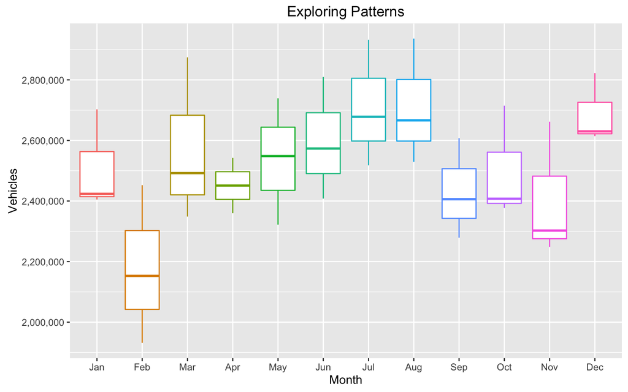

```r
lax.training %>%
  mutate(month=factor(format(reporting_month ,"%b"), level=c("Jan", "Feb", "Mar", "Apr", "May", "Jun", "Jul", "Aug", "Sep", "Oct", "Nov", "Dec"))) %>%
  ggplot(aes(x=month, y=vehicles, color=month))+
  geom_boxplot()+
  ggtitle("Exploring Patterns")+
  scale_x_discrete(name="Month")+
  scale_y_continuous(name="Vehicles",
                     breaks=seq(0,4000000,200000),
                     labels=format(seq(0,4000000,200000), big.mark=",", scientific=F))+
  theme(legend.position="none")
```

## 2.3 Stationary

Before proceeding, we’ll need to make our data stationary over time, so we’ll start with an integrated of order 1 and see if it becomes stationary.

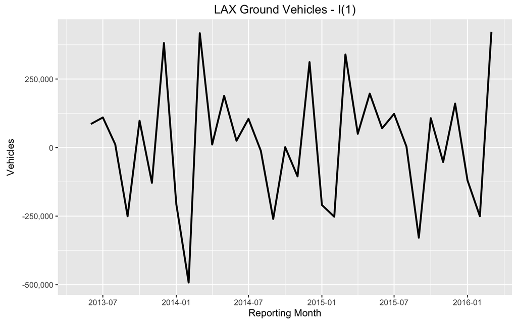

```r
lax.training %>%
  mutate(diff1=vehicles-dplyr::lag(vehicles, 1)) %>%
  ggplot(aes(x=reporting_month, y=diff1))+
  geom_line(size=1)+
  ggtitle("LAX Ground Vehicles - I(1)")+
  scale_x_datetime(name="Reporting Month")+
  scale_y_continuous(name="Vehicles",
                     breaks=seq(-1000000,1000000,250000),
                     labels=format(seq(-1000000,1000000,250000), big.mark=",", scientific=F))
```

### 2.3.1 ACF

Our Autocorrelation Function (ACF) shows significance at lag 12 and almost significance at lag 24. This makes intuitive sense as travel data is seasonal on an annual level.

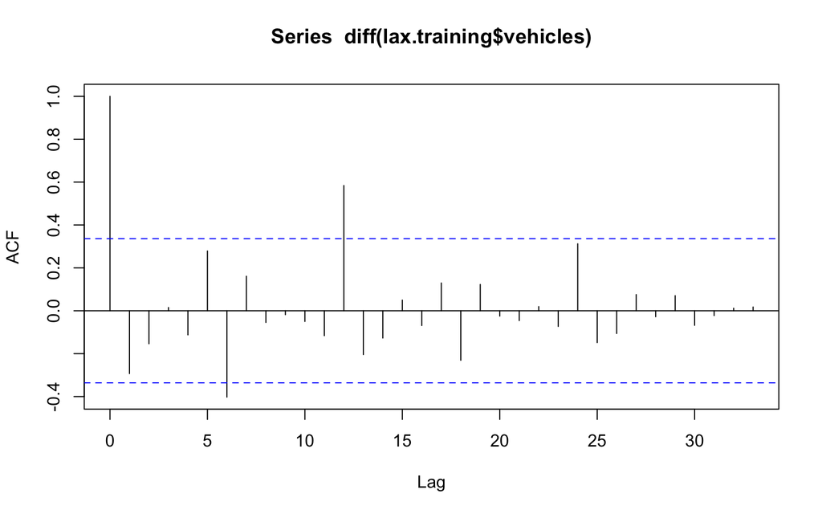

```r
acf(diff(lax.training$vehicles),
     lag.max=sum(!is.na(lax.training$vehicles)))
```

### 2.3.2 Ljung-Box

Our Ljung-Box test shows statistical significance, validating I(1) is stationary.

```r
# http://www.statosphere.com.au/check-time-series-stationary-r/
Box.test(diff(lax.training$vehicles),
         lag=20,
         type="Ljung-Box")
```

```
##
##  Box-Ljung test
##
## data:  diff(lax.training$vehicles)
## X-squared = 46.621, df = 20, p-value = 0.0006619
```

### 2.3.3 ADF

Our Augmented Dickey-Fuller (ADF) test shows statistical significance at a p-value < 0.05, validating I(1) is stationary.

```r
adf.test(diff(lax.training$vehicles), alternative="stationary")
```

```
##
##  Augmented Dickey-Fuller Test
##
## data:  diff(lax.training$vehicles)
## Dickey-Fuller = -4.0279, Lag order = 3, p-value = 0.02033
## alternative hypothesis: stationary
```

### 2.3.4 KPSS

Our Kwiatkowski-Phillips-Schmidt-Shin (KPSS) test shows no statistical significance at a p-value < 0.05, validating I(1) is stationary.

```r
kpss.test(diff(lax.training$vehicles))
```

```
##
##  KPSS Test for Level Stationarity
##
## data:  diff(lax.training$vehicles)
## KPSS Level = 0.034776, Truncation lag parameter = 1, p-value = 0.1
```

# 3 Model Selection

We’ll run forecasting using our three models:

- STL Decomposition
- Holt-Winters Exponential Smoothing
- Arima

## 3.1 STL Decomposition

### 3.1.1 Analysis

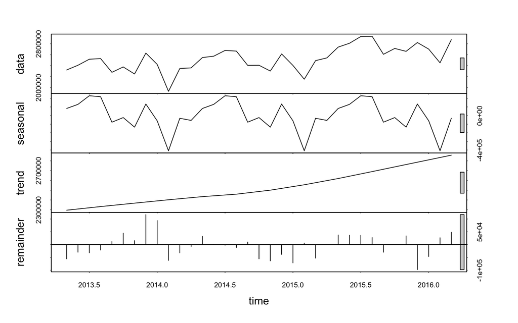

```r
lax.stl<-stl(lax.ts12, s.window="periodic", t.window = 24)
plot(lax.stl)
```

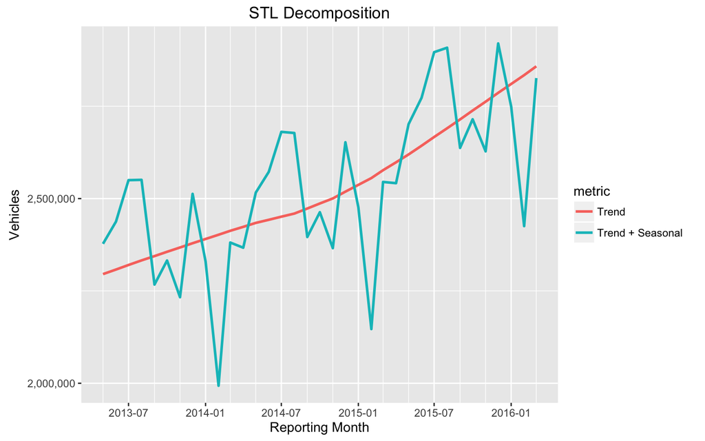

```r
lax.training %>%
  mutate("Trend"=lax.stl$time.series[,2],
         "Trend + Seasonal"=lax.stl$time.series[,1]+lax.stl$time.series[,2]) %>%
  dplyr::rename(actuals=vehicles) %>%
  gather(metric, value, actuals:`Trend + Seasonal`) %>%
  mutate(metric=factor(metric, levels=c("Trend", "Trend + Seasonal"))) %>%
  filter(metric!="actuals") %>%
  ggplot(aes(x=reporting_month, y=value, color=metric, group=metric))+
  geom_line(size=1)+
  ggtitle("STL Decomposition")+
  scale_x_datetime(name="Reporting Month",
                   date_minor_breaks="2 months")+
  scale_y_continuous(name="Vehicles",
                     breaks=seq(0,10000000,500000),
                     labels=format(seq(0,10000000,500000), big.mark=",", scientific=F))
```

### 3.1.2 Validation

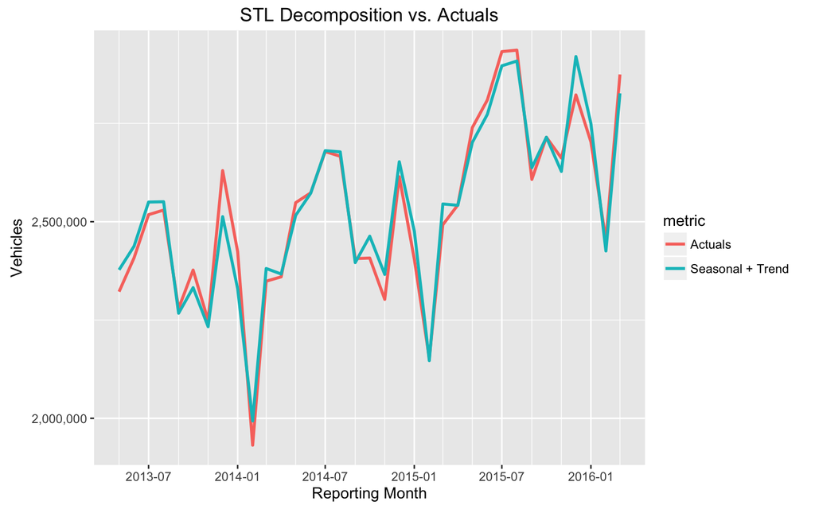

```r
lax.training %>%
  mutate("Seasonal + Trend"=lax.stl$time.series[,1]+lax.stl$time.series[,2]) %>%
  dplyr::rename(Actuals=vehicles) %>%
  gather(metric, value, Actuals:`Seasonal + Trend`) %>%
  ggplot(aes(x=reporting_month, y=value, color=metric, group=metric))+
  geom_line(size=1)+
  ggtitle("STL Decomposition vs. Actuals")+
  scale_x_datetime(name="Reporting Month",
                   date_minor_breaks="2 months")+
  scale_y_continuous(name="Vehicles",
                     breaks=seq(0,10000000,500000),
                     labels=format(seq(0,10000000,500000), big.mark=",", scientific=F))
```

```r
lax.stl.fcast<-data.frame(forecast.stl(lax.stl, h=validation_periods, method="ets"))
lax.stl.fcast %>%
  get_table()
```

|  | Point.Forecast | Lo.80 | Hi.80 | Lo.95 | Hi.95 |
| --- | --- | --- | --- | --- | --- |
| Apr 2016 | 2,854,059 | 2,781,038 | 2,927,080 | 2,742,384 | 2,965,734 |
| May 2016 | 3,014,717 | 2,927,119 | 3,102,316 | 2,880,747 | 3,148,687 |
| Jun 2016 | 3,084,528 | 2,984,273 | 3,184,783 | 2,931,202 | 3,237,855 |

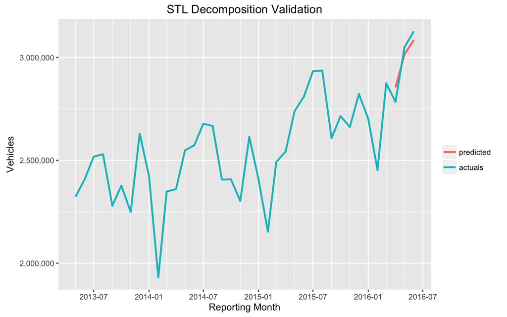

```r
lax.stl.predict<-lax.test %>%
  dplyr::rename(actuals=vehicles) %>%
  mutate(predicted=lax.stl.fcast$Point.Forecast)

lax.training %>%
  dplyr::rename(actuals=vehicles) %>%
  gather(metric, value, -reporting_month) %>%
  bind_rows(lax.stl.predict %>%
              gather(metric, value, -reporting_month)) %>%
  ggplot(aes(x=reporting_month, y=value,
             color=factor(metric,
                          levels=c("predicted", "actuals"))))+
  geom_line(size=1)+
  ggtitle("STL Decomposition Validation")+
  scale_x_datetime(name="Reporting Month",
                   date_minor_breaks="2 months")+
  scale_y_continuous(name="Vehicles",
                     breaks=seq(0,10000000,500000),
                     labels=format(seq(0,10000000,500000), big.mark=",", scientific=F))+
  scale_color_hue(name="")
```

```r
stl_validation<-data.frame(model="STL",
                           mae=get_mae(lax.stl.predict$actuals, lax.stl.predict$predicted),
                           mape=get_mape(lax.stl.predict$actuals, lax.stl.predict$predicted),
                           mse=get_mse(lax.stl.predict$actuals, lax.stl.predict$predicted),
                           mpe=get_mpe(lax.stl.predict$actuals, lax.stl.predict$predicted),
                           stringsAsFactors=F)
stl_validation %>%
  get_table(4)
```

| model | mae | mape | mse | mpe |
| --- | --- | --- | --- | --- |
| STL | 49,374.81 | 0.0168 | 2,672,397,950 | -1e-04 |

```r
forecast_validation<-stl_validation
```

## 3.2 Holt-Winters Exponential Smoothing

### 3.2.1 Analysis

```r
# lax.hw<-HoltWinters(lax.ts12, gamma=F) # trend only
lax.hw<-HoltWinters(lax.ts12) # seasonal + trend
lax.hw
```

```
## Holt-Winters exponential smoothing with trend and additive seasonal component.
##
## Call:
## HoltWinters(x = lax.ts12)
##
## Smoothing parameters:
##  alpha: 0.0466399
##  beta : 1
##  gamma: 1
##
## Coefficients:
##            [,1]
## a   2864807.764
## b     33785.349
## s1     5489.864
## s2   182580.965
## s3   230187.267
## s4   327370.776
## s5   302049.128
## s6   -54961.301
## s7    20208.747
## s8   -69865.707
## s9    56780.354
## s10  -96252.978
## s11 -378702.415
## s12    9632.236
```

### 3.2.2 Validation

```r
lax.hw.fcast<-data.frame(forecast.HoltWinters(lax.hw, h=validation_periods))
lax.hw.fcast %>%
  get_table()
```

|  | Point.Forecast | Lo.80 | Hi.80 | Lo.95 | Hi.95 |
| --- | --- | --- | --- | --- | --- |
| Apr 2016 | 2,904,083 | 2,820,378 | 2,987,788 | 2,776,068 | 3,032,098 |
| May 2016 | 3,114,959 | 3,030,891 | 3,199,028 | 2,986,388 | 3,243,530 |
| Jun 2016 | 3,196,351 | 3,111,471 | 3,281,231 | 3,066,538 | 3,326,164 |

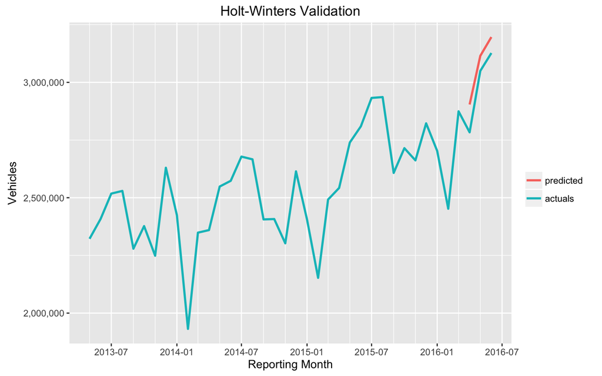

```r
lax.hw.predict<-lax.test %>%
  dplyr::rename(actuals=vehicles) %>%
  mutate(predicted=lax.hw.fcast$Point.Forecast)

lax.training %>%
  dplyr::rename(actuals=vehicles) %>%
  gather(metric, value, -reporting_month) %>%
  bind_rows(lax.hw.predict %>%
              gather(metric, value, -reporting_month)) %>%
  ggplot(aes(x=reporting_month, y=value,
             color=factor(metric,
                          levels=c("predicted", "actuals"))))+
  geom_line(size=1)+
  ggtitle("Holt-Winters Validation")+
  scale_x_datetime(name="Reporting Month",
                   date_minor_breaks="2 months")+
  scale_y_continuous(name="Vehicles",
                     breaks=seq(0,10000000,500000),
                     labels=format(seq(0,10000000,500000), big.mark=",", scientific=F))+
  scale_color_hue(name="")
```

```r
hw_validation<-data.frame(model="Holt-Winters",
                          mae=get_mae(lax.hw.predict$actuals, lax.hw.predict$predicted),
                          mape=get_mape(lax.hw.predict$actuals, lax.hw.predict$predicted),
                          mse=get_mse(lax.hw.predict$actuals, lax.hw.predict$predicted),
                          mpe=get_mpe(lax.hw.predict$actuals, lax.hw.predict$predicted))
hw_validation %>%
  get_table(4)
```

| model | mae | mape | mse | mpe |
| --- | --- | --- | --- | --- |
| Holt-Winters | 85,048.83 | 0.029 | 7,868,504,847 | -0.029 |

```r
forecast_validation<-forecast_validation %>%
  bind_rows(hw_validation)
```

## 3.3 Arima

### 3.3.1 Analysis

```r
lax.autoarima<-auto.arima(lax.ts12, allowdrift=F)
lax.autoarima
```

```
## Series: lax.ts12
## ARIMA(0,1,1)(0,1,0)[12]
##
## Coefficients:
##           ma1
##       -0.3585
## s.e.   0.1903
##
## sigma^2 estimated as 5.971e+09:  log likelihood=-278.38
## AIC=560.76   AICc=561.39   BIC=562.94
```

### 3.3.2 Validation

```r
lax.autoarima.fcast<-data.frame(forecast(lax.autoarima, h=validation_periods))
lax.autoarima.fcast %>%
  get_table()
```

|  | Point.Forecast | Lo.80 | Hi.80 | Lo.95 | Hi.95 |
| --- | --- | --- | --- | --- | --- |
| Apr 2016 | 2,892,655 | 2,793,625 | 2,991,684 | 2,741,202 | 3,044,108 |
| May 2016 | 3,089,515 | 2,971,858 | 3,207,172 | 2,909,574 | 3,269,456 |
| Jun 2016 | 3,159,753 | 3,026,039 | 3,293,467 | 2,955,255 | 3,364,251 |

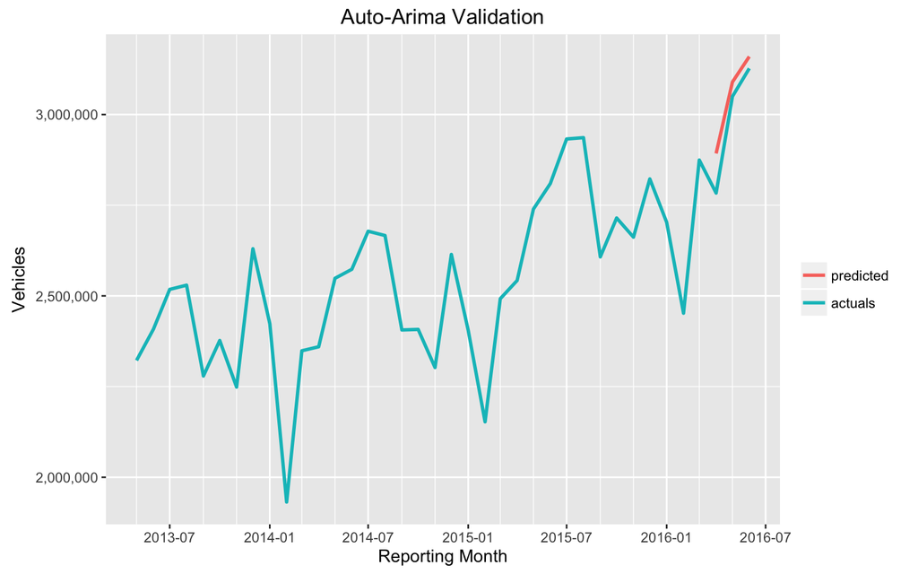

```r
lax.autoarima.predict<-lax.test %>%
  dplyr::rename(actuals=vehicles) %>%
  mutate(predicted=lax.autoarima.fcast$Point.Forecast)

lax.training %>%
  dplyr::rename(actuals=vehicles) %>%
  gather(metric, value, -reporting_month) %>%
  bind_rows(lax.autoarima.predict %>%
              gather(metric, value, -reporting_month)) %>%
  ggplot(aes(x=reporting_month, y=value,
             color=factor(metric,
                          levels=c("predicted", "actuals"))))+
  geom_line(size=1)+
  ggtitle("Auto-Arima Validation")+
  scale_x_datetime(name="Reporting Month",
                   date_minor_breaks="2 months")+
  scale_y_continuous(name="Vehicles",
                     breaks=seq(0,10000000,500000),
                     labels=format(seq(0,10000000,500000), big.mark=",", scientific=F))+
  scale_color_hue(name="")
```

```r
arima_validation<-data.frame(model="Arima",
                             mae=get_mae(lax.autoarima.predict$actuals, lax.autoarima.predict$predicted),
                             mape=get_mape(lax.autoarima.predict$actuals, lax.autoarima.predict$predicted),
                             mse=get_mse(lax.autoarima.predict$actuals, lax.autoarima.predict$predicted),
                             mpe=get_mpe(lax.autoarima.predict$actuals, lax.autoarima.predict$predicted))

arima_validation %>%
  get_table(4)
```

| model | mae | mape | mse | mpe |
| --- | --- | --- | --- | --- |
| Arima | 60,558.61 | 0.0209 | 4,858,125,254 | -0.0209 |

```r
forecast_validation<-forecast_validation %>%
  bind_rows(arima_validation)
```

## 3.4 Model Comparison

We compared our models using the following error metrics:

- Mean Absolute Error
- Mean Absolute Percentage Error
- Mean Squared Error
- Mean Percentage Error

```r
forecast_validation %>%
  get_table()
```

| model | mae | mape | mse | mpe |
| --- | --- | --- | --- | --- |
| STL | 49,374.81 | 0.02 | 2,672,397,950 | 0.00 |
| Holt-Winters | 85,048.83 | 0.03 | 7,868,504,847 | -0.03 |
| Arima | 60,558.61 | 0.02 | 4,858,125,254 | -0.02 |

Our STL Decomposition model performed the best

# 4 Forecasting

We’ll use our STL Decomposition to project LAX ground vehicles 2 years out

```r
lax.fcast<-data.frame(forecast.stl(lax.stl, h=24+validation_periods, method="ets"))
lax.fcast %>%
  get_table()
```

|  | Point.Forecast | Lo.80 | Hi.80 | Lo.95 | Hi.95 |
| --- | --- | --- | --- | --- | --- |
| Apr 2016 | 2,854,059 | 2,781,038 | 2,927,080 | 2,742,384 | 2,965,734 |
| May 2016 | 3,014,717 | 2,927,119 | 3,102,316 | 2,880,747 | 3,148,687 |
| Jun 2016 | 3,084,528 | 2,984,273 | 3,184,783 | 2,931,202 | 3,237,855 |
| Jul 2016 | 3,206,524 | 3,094,877 | 3,318,171 | 3,035,774 | 3,377,273 |
| Aug 2016 | 3,217,131 | 3,095,001 | 3,339,261 | 3,030,350 | 3,403,913 |
| Sep 2016 | 2,943,955 | 2,812,033 | 3,075,876 | 2,742,198 | 3,145,711 |
| Oct 2016 | 3,019,492 | 2,878,325 | 3,160,659 | 2,803,595 | 3,235,389 |
| Nov 2016 | 2,930,651 | 2,780,682 | 3,080,619 | 2,701,294 | 3,160,008 |
| Dec 2016 | 3,220,991 | 3,062,591 | 3,379,392 | 2,978,738 | 3,463,244 |
| Jan 2017 | 3,048,465 | 2,881,945 | 3,214,985 | 2,793,794 | 3,303,135 |
| Feb 2017 | 2,722,763 | 2,548,392 | 2,897,135 | 2,456,085 | 2,989,442 |
| Mar 2017 | 3,121,837 | 2,939,846 | 3,303,828 | 2,843,505 | 3,400,168 |
| Apr 2017 | 3,119,221 | 2,929,815 | 3,308,628 | 2,829,549 | 3,408,894 |
| May 2017 | 3,279,880 | 3,083,238 | 3,476,522 | 2,979,142 | 3,580,618 |
| Jun 2017 | 3,349,691 | 3,145,973 | 3,553,408 | 3,038,132 | 3,661,250 |
| Jul 2017 | 3,471,686 | 3,261,036 | 3,682,336 | 3,149,525 | 3,793,847 |
| Aug 2017 | 3,482,294 | 3,264,841 | 3,699,747 | 3,149,728 | 3,814,859 |
| Sep 2017 | 3,209,117 | 2,984,977 | 3,433,257 | 2,866,325 | 3,551,909 |
| Oct 2017 | 3,284,654 | 3,053,934 | 3,515,375 | 2,931,798 | 3,637,511 |
| Nov 2017 | 3,195,813 | 2,958,608 | 3,433,018 | 2,833,039 | 3,558,587 |
| Dec 2017 | 3,486,154 | 3,242,552 | 3,729,755 | 3,113,598 | 3,858,710 |
| Jan 2018 | 3,313,627 | 3,063,710 | 3,563,544 | 2,931,413 | 3,695,842 |
| Feb 2018 | 2,987,926 | 2,731,768 | 3,244,084 | 2,596,166 | 3,379,685 |
| Mar 2018 | 3,386,999 | 3,124,669 | 3,649,329 | 2,985,799 | 3,788,199 |
| Apr 2018 | 3,384,384 | 3,115,944 | 3,652,824 | 2,973,841 | 3,794,927 |
| May 2018 | 3,545,042 | 3,270,551 | 3,819,533 | 3,125,245 | 3,964,840 |
| Jun 2018 | 3,614,853 | 3,334,366 | 3,895,341 | 3,185,885 | 4,043,822 |

```r
lax_forecasted<-data.frame(reporting_month=strptime(gsub(" ", "-", paste("01", row.names(lax.fcast), sep="-")), format="%d-%b-%Y"),
                              metric="predicted",
                              value=lax.fcast$Point.Forecast)
lax_forecasted %>%
  dplyr::select(-metric) %>%
  get_table()
```

| reporting_month | value |
| --- | --- |
| 2016-04-01 | 2,854,059 |
| 2016-05-01 | 3,014,717 |
| 2016-06-01 | 3,084,528 |
| 2016-07-01 | 3,206,524 |
| 2016-08-01 | 3,217,131 |
| 2016-09-01 | 2,943,955 |
| 2016-10-01 | 3,019,492 |
| 2016-11-01 | 2,930,651 |
| 2016-12-01 | 3,220,991 |
| 2017-01-01 | 3,048,465 |
| 2017-02-01 | 2,722,763 |
| 2017-03-01 | 3,121,837 |
| 2017-04-01 | 3,119,221 |
| 2017-05-01 | 3,279,880 |
| 2017-06-01 | 3,349,691 |
| 2017-07-01 | 3,471,686 |
| 2017-08-01 | 3,482,294 |
| 2017-09-01 | 3,209,117 |
| 2017-10-01 | 3,284,654 |
| 2017-11-01 | 3,195,813 |
| 2017-12-01 | 3,486,154 |
| 2018-01-01 | 3,313,627 |
| 2018-02-01 | 2,987,926 |
| 2018-03-01 | 3,386,999 |
| 2018-04-01 | 3,384,384 |
| 2018-05-01 | 3,545,042 |
| 2018-06-01 | 3,614,853 |

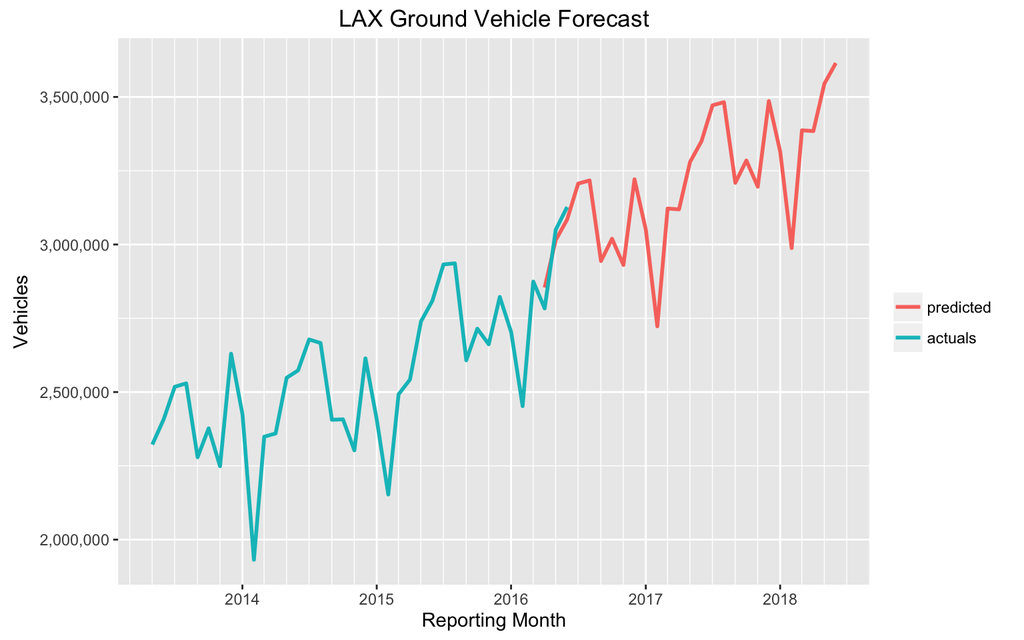

```r
# lax_forecasted %>%
#   filter(year(reporting_month)=="2017") %>%
#   group_by(year(reporting_month)) %>%
#   summarize(vehicles=sum(value))

lax_ground_vehicle_traffic_volume_cleaned %>%
  dplyr::rename(actuals=vehicles) %>%
  gather(metric, value, -reporting_month) %>%
  bind_rows(lax_forecasted) %>%
  ggplot(aes(x=reporting_month, y=value,
             color=factor(metric,
                          levels=c("predicted", "actuals"))))+
  geom_line(size=1)+
  ggtitle("LAX Ground Vehicle Forecast")+
  scale_x_datetime(name="Reporting Month",
                   date_minor_breaks="2 months")+
  scale_y_continuous(name="Vehicles",
                     breaks=seq(0,10000000,500000),
                     labels=format(seq(0,10000000,500000), big.mark=",", scientific=F))+
  scale_color_hue(name="")
```

# 5 Appendix

## 5.1 Data Source

Our raw data for LAX Ground Vehicle Traffic Volume came from www.data.gov. See [here](https://catalog.data.gov/dataset/los-angeles-international-airport-ground-vehicle-traffic-volume-cb231) for the original data source.

## 5.2 Data Quality Check

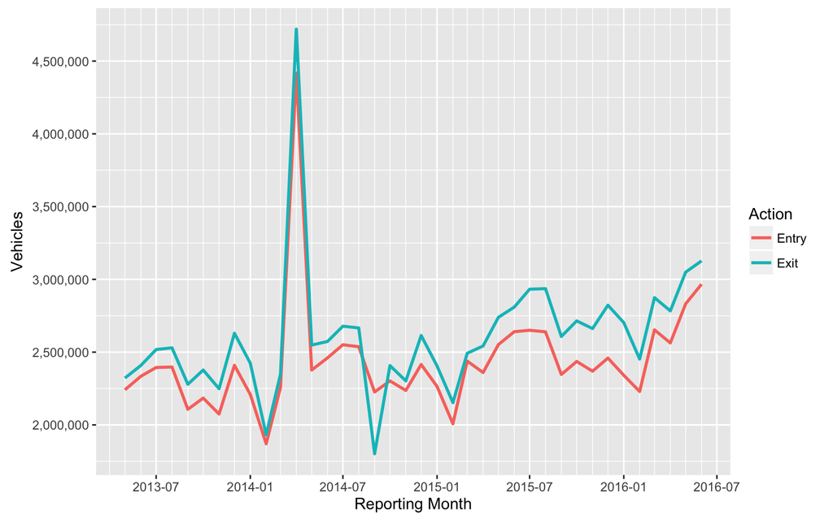

```r
lax_ground_vehicle_traffic_volume %>%
  group_by(reporting_month, action) %>%
  summarize(vehicles=sum(vehicles)) %>%
  ungroup() %>%
  ggplot(aes(x=reporting_month, y=vehicles, color=action, group=action))+
  geom_line(size=1)+
  scale_x_datetime(name="Reporting Month",
                   date_minor_breaks="1 months")+
  scale_y_continuous(name="Vehicles",
                     breaks=seq(0,10000000,500000),
                     labels=format(seq(0,10000000,500000), big.mark=",", scientific=F))+
  scale_color_discrete(name="Action")+
  theme()
```

We see three odd things about our data, and will do what we can to fix them:

1. Month of 2014-04 has an unusual spike in trip volume
2. Month of 2014-09 is the only month where entries out pace exists
3. Exits outpace entries every month

### 5.2.1 Part 1

Month of 2014-04 has an unusual spike in trip volume.

```r
lax_ground_vehicle_traffic_volume %>%
  filter(year(reporting_month)==2014,
         month(reporting_month)==4) %>%
  get_table()
```

| reporting_month | action | level | vehicles |
| --- | --- | --- | --- |
| 2014-04-01 | Entry | Lower Level | 1,027,606 |
| 2014-04-01 | Entry | Lower Level | 1,027,606 |
| 2014-04-01 | Entry | Upper Level | 1,181,556 |
| 2014-04-01 | Entry | Upper Level | 1,181,556 |
| 2014-04-01 | Exit | Lower Level | 1,691,869 |
| 2014-04-01 | Exit | Lower Level | 1,691,869 |
| 2014-04-01 | Exit | Upper Level | 667,872 |
| 2014-04-01 | Exit | Upper Level | 667,872 |

Investigating our raw data shows dup rows for this month, so we’ll go ahead and dedup rows for that month.

```r
lax_ground_vehicle_traffic_volume_edit_1<-lax_ground_vehicle_traffic_volume %>%
  unique()

lax_ground_vehicle_traffic_volume_edit_1 %>%
  filter(year(reporting_month)==2014,
         month(reporting_month)==4) %>%
  get_table()
```

| reporting_month | action | level | vehicles |
| --- | --- | --- | --- |
| 2014-04-01 | Entry | Lower Level | 1,027,606 |
| 2014-04-01 | Entry | Upper Level | 1,181,556 |
| 2014-04-01 | Exit | Lower Level | 1,691,869 |
| 2014-04-01 | Exit | Upper Level | 667,872 |

### 5.2.2 Part 2

We see month of 2014-09 is the only month where entries out pace exists.

We’ll correct for this by editing exits for that month to be the “# of entries in 2014-09” + “average difference between exits and entries”.

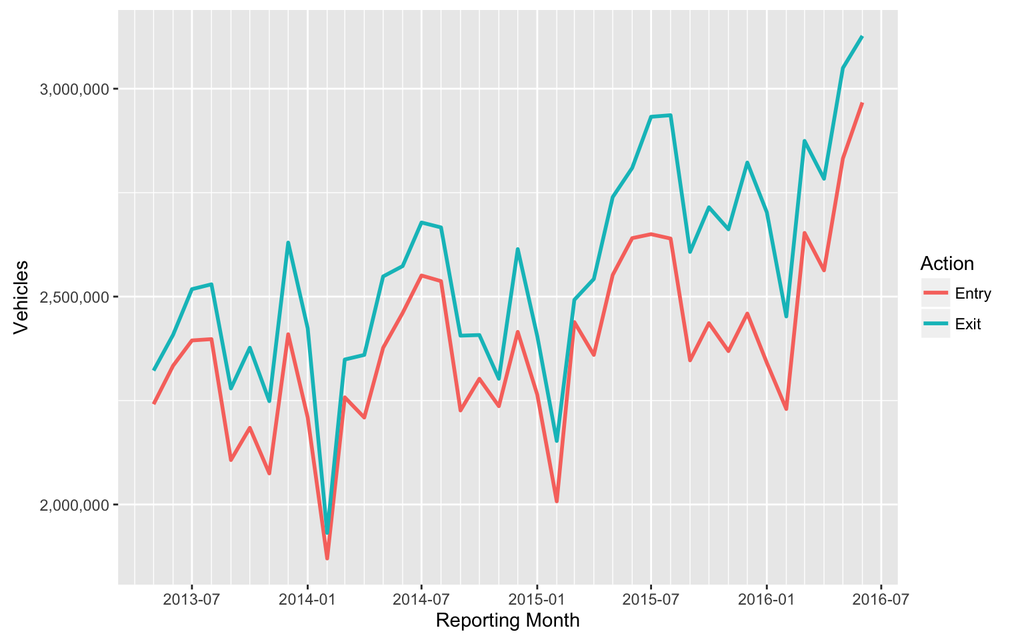

```r
mean_exit_entry_delta<-lax_ground_vehicle_traffic_volume_edit_1 %>%
  group_by(reporting_month, action) %>%
  summarize(vehicles=sum(vehicles)) %>%
  ungroup() %>%
  spread(action, vehicles) %>%
  mutate(exit_entry_delta=ifelse(Exit>Entry, Exit-Entry, NA)) %>%
  .$exit_entry_delta %>%
  mean(na.rm=T)

lax_ground_vehicle_traffic_volume_edit_2<-lax_ground_vehicle_traffic_volume_edit_1 %>%
  group_by(reporting_month, action) %>%
  summarize(vehicles=sum(vehicles)) %>%
  ungroup() %>%
  spread(action, vehicles) %>%
  mutate(Exit=ifelse(reporting_month==ymd("2014-09-01", tz="America/Los_Angeles"), Entry+mean_exit_entry_delta, Exit)) %>%
  gather(action, vehicles, -reporting_month)

lax_ground_vehicle_traffic_volume_edit_2 %>%
  ggplot(aes(x=reporting_month, y=vehicles, color=action, group=action))+
  geom_line(size=1)+
  scale_x_datetime(name="Reporting Month",
                   date_minor_breaks="1 months")+
  scale_y_continuous(name="Vehicles",
                     breaks=seq(0,10000000,500000),
                     labels=format(seq(0,10000000,500000), big.mark=",", scientific=F))+
  scale_color_discrete(name="Action")
```

### 5.2.3 Part 3

Lastly, exits outpace entries every month. In reality, a vehicle that exits had to have entered at some point, and vice versa.

For our analysis, we only need one number per month, so we’ll use the maximum of each months entry or exit.

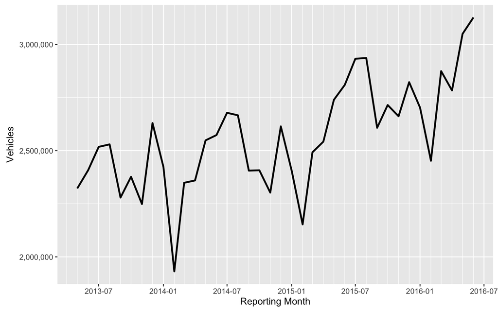

```r
lax_ground_vehicle_traffic_volume_cleaned<-lax_ground_vehicle_traffic_volume_edit_2 %>%
  group_by(reporting_month) %>%
  summarize(vehicles=max(vehicles)) %>%
  ungroup()

lax_ground_vehicle_traffic_volume_cleaned %>%
  ggplot(aes(x=reporting_month, y=vehicles))+
  geom_line(size=1)+
  scale_x_datetime(name="Reporting Month",
                   date_minor_breaks="1 months")+
  scale_y_continuous(name="Vehicles",
                     breaks=seq(0,10000000,500000),
                     labels=format(seq(0,10000000,500000), big.mark=",", scientific=F))
```